# FRED 30Y Fixed Rate Mortgage x Housing Starts

Scott Cohn

June 22

# Clean + Tidy + Mutate

```r
# load gdpdeflator
df_gdpdef <- read.csv("fred_data/GDPDEF.csv")

# convert date + inflation
df_gdpdef$GDPDEF <- as.numeric(df_gdpdef$GDPDEF)

df_gdpdef <- df_gdpdef %>%
  mutate(DATE = as.Date(df_gdpdef$DATE, format = "%Y-%m-%d"),
         inflation = ((GDPDEF - lag(GDPDEF, default = 0))/lag(GDPDEF, default = 0))*100)

# change inf
df_gdpdef[1, 3] <- 0

# load m30 and houst
df <- read_csv("fred_data/m30_x_houst.csv")
# merge on date
df <- right_join(df_gdpdef, df, by = "DATE")

# carry last NA on gdpdef
df <- df %>%
  mutate(
    GDPDEF = na.locf(df$GDPDEF),
    inflation = na.locf(df$inflation)
  )

# rename
df <- df %>%
  rename(c("houst" = "HOUST", "m30" = "MORTGAGE30US"))

# as numeric
df <- df %>%
  mutate(houst = as.numeric(df$houst),
         m30 = as.numeric(df$m30))

# real m30 (rm30)
df <- df %>% mutate(rm30 = m30 - inflation)
```

# Plots

### houst x date

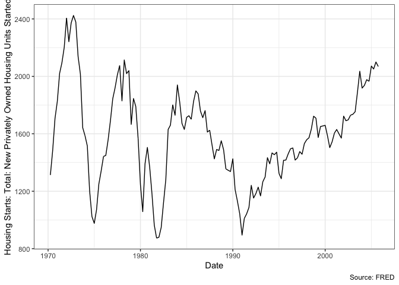

### houst x rm30 (1yrlag)

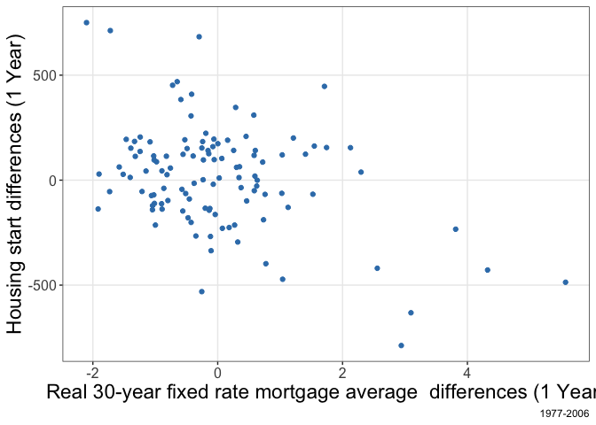

### houst x rm30

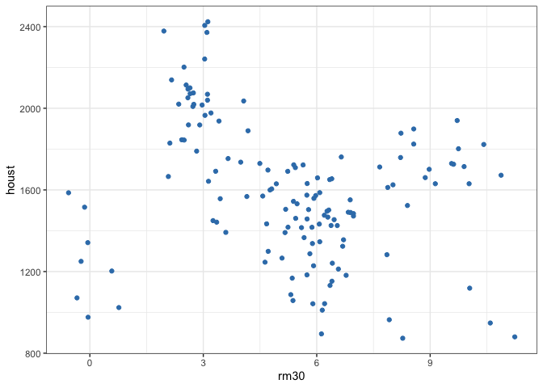

### m30 x date

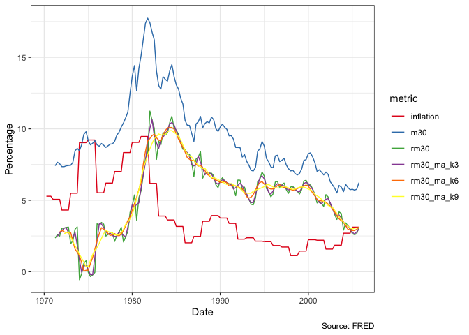

### Dual axis

Ignore this for now.

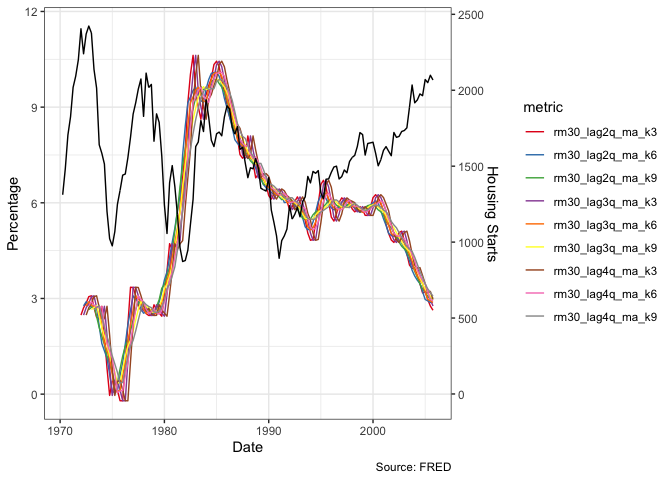

# Lagged Correlations (1977 – 2006)

```r
df_lag_diffs <- df %>%
  select(DATE, houst, rm30) %>%
  # lagged diffs (1 year // 4Qs)
  mutate(houst_lag_diff_1q = houst - lag(df$houst, 1, na.pad = TRUE),    # 1Q
         houst_lag_diff_2q = houst - lag(df$houst, 2, na.pad = TRUE),    # 2Q
         houst_lag_diff_3q = houst - lag(df$houst, 3, na.pad = TRUE),
         houst_lag_diff_4q = houst - lag(df$houst, 4, na.pad = TRUE),
         houst_lag_diff_5q = houst - lag(df$houst, 5, na.pad = TRUE),
         houst_lag_diff_6q = houst - lag(df$houst, 6, na.pad = TRUE),
         houst_lag_diff_7q = houst - lag(df$houst, 7, na.pad = TRUE),
         houst_lag_diff_8q = houst - lag(df$houst, 8, na.pad = TRUE),
         houst_lag_diff_9q = houst - lag(df$houst, 9, na.pad = TRUE),

         rm30_lag_diff_1q = rm30 - lag(df$rm30, 1, na.pad = TRUE),    # 1Q
         rm30_lag_diff_2q = rm30 - lag(df$rm30, 2, na.pad = TRUE),    # 2Q
         rm30_lag_diff_3q = rm30 - lag(df$rm30, 3, na.pad = TRUE),
         rm30_lag_diff_4q = rm30 - lag(df$rm30, 4, na.pad = TRUE),
         rm30_lag_diff_5q = rm30 - lag(df$rm30, 5, na.pad = TRUE),
         rm30_lag_diff_6q = rm30 - lag(df$rm30, 6, na.pad = TRUE),
         rm30_lag_diff_7q = rm30 - lag(df$rm30, 7, na.pad = TRUE),
         rm30_lag_diff_8q = rm30 - lag(df$rm30, 8, na.pad = TRUE),
         rm30_lag_diff_9q = rm30 - lag(df$rm30, 9, na.pad = TRUE)
         ) %>%
  #filter(DATE > "1977-01-01" & DATE < "1985-01-01") %>%
  filter(DATE > "1977-01-01" & DATE < "2006-01-01")
```

## First Differences: Simple OLS of diff starts on diff mortgages (by quarter)

1 year lag for `houst` regressed on 1 year lag for `rm30`.

```r
ols_simple_1y <- lm(houst_lag_diff_4q ~ rm30_lag_diff_4q, data = df_lag_diffs)
#summary(ols_simple_1y)
tab_model(ols_simple_1y)
```

|  | houst_lag_diff_4q |  |  |
| --- | --- | --- | --- |
| Predictors | Estimates | CI | p |
| (Intercept) | 14.19 | -27.81 – 56.18 | 0.505 |
| rm30_lag_diff_4q | -77.45 | -110.77 – -44.13 | **<0.001** |
| Observations | 115 |  |  |
| R<sup>2</sup> / R<sup>2</sup> adjusted | 0.158 / 0.151 |  |  |

Check for stationarity of var:

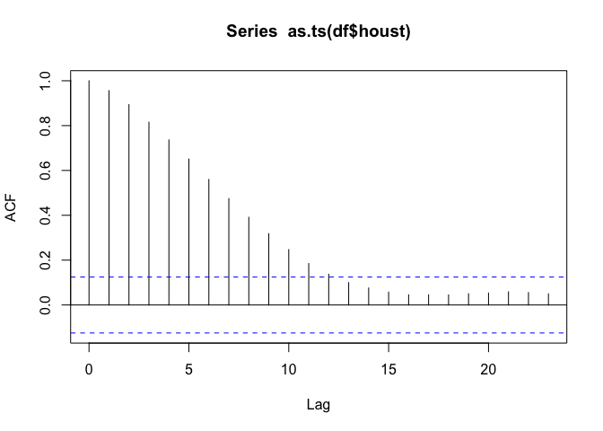

```r
acf(as.ts(df$houst), na.action = na.pass, plot = TRUE)
```

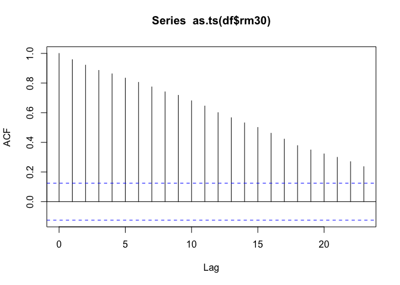

```r
acf(as.ts(df$rm30), na.action = na.pass, plot = TRUE)
```

Check for autocorrelation:

```r
res <- ols_simple_1y$res
n <- length(res)
ols_1y_autocorr <- lm(res[-n] ~ res[-1])
# summary(ols_1y_autocorr)
tab_model(ols_1y_autocorr)
```

|  | res[-n] |  |  |
| --- | --- | --- | --- |
| Predictors | Estimates | CI | p |
| (Intercept) | 1.85 | -26.44 – 30.14 | 0.897 |
| res[-1] | 0.75 | 0.63 – 0.88 | **<0.001** |
| Observations | 114 |  |  |
| R<sup>2</sup> / R<sup>2</sup> adjusted | 0.554 / 0.550 |  |  |

Since the coefficient for `res[-1]` is significant, we have evidence for autocorrelation.

## diff starts on diff mortages

t-1, t-2, t-3, t-4, … t-8 (where the numbers refer to quarters (look at the pattern of the coefficients on the lagged mortages)

### 1Q

1 quarter lag for `houst` regressed on 1 quarter lag for `rm30`.

```r
ols_simple_1q_diff_diff <- lm(houst_lag_diff_1q ~ rm30_lag_diff_1q, data = df_lag_diffs)
#summary(ols_simple_1q_diff_diff)
tab_model(ols_simple_1q_diff_diff)
```

|  | houst_lag_diff_1q |  |  |
| --- | --- | --- | --- |
| Predictors | Estimates | CI | p |
| (Intercept) | 1.98 | -19.78 – 23.74 | 0.857 |
| rm30_lag_diff_1q | -5.96 | -38.43 – 26.51 | 0.717 |
| Observations | 115 |  |  |
| R<sup>2</sup> / R<sup>2</sup> adjusted | 0.001 / -0.008 |  |  |

### 2Q

2 quarter lag for `houst` regressed on 2 quarter lag for `rm30`.

```r
ols_simple_2q_diff_diff <- lm(houst_lag_diff_2q ~ rm30_lag_diff_2q, data = df_lag_diffs)
#summary(ols_simple_2q_diff_diff)
tab_model(ols_simple_2q_diff_diff)
```

|  | houst_lag_diff_2q |  |  |
| --- | --- | --- | --- |
| Predictors | Estimates | CI | p |
| (Intercept) | 5.48 | -25.13 – 36.09 | 0.724 |
| rm30_lag_diff_2q | -47.28 | -80.63 – -13.93 | **0.006** |
| Observations | 115 |  |  |
| R<sup>2</sup> / R<sup>2</sup> adjusted | 0.065 / 0.057 |  |  |

### 3Q

3 quarter lag for `houst` regressed on 3 quarter lag for `rm30`.

```r
ols_simple_3q_diff_diff <- lm(houst_lag_diff_3q ~ rm30_lag_diff_3q, data = df_lag_diffs)
#summary(ols_simple_3q_diff_diff)
tab_model(ols_simple_3q_diff_diff)
```

|  | houst_lag_diff_3q |  |  |
| --- | --- | --- | --- |
| Predictors | Estimates | CI | p |
| (Intercept) | 9.31 | -28.52 – 47.15 | 0.627 |
| rm30_lag_diff_3q | -61.34 | -94.44 – -28.23 | **<0.001** |
| Observations | 115 |  |  |
| R<sup>2</sup> / R<sup>2</sup> adjusted | 0.107 / 0.099 |  |  |

### 4Q

4 quarter lag for `houst` regressed on 4 quarter lag for `rm30`.

```r
ols_simple_4q_diff <- lm(houst_lag_diff_4q ~ rm30_lag_diff_4q, data = df_lag_diffs)
#summary(ols_simple_4q_diff)
tab_model(ols_simple_4q_diff)
```

|  | houst_lag_diff_4q |  |  |
| --- | --- | --- | --- |
| Predictors | Estimates | CI | p |
| (Intercept) | 14.19 | -27.81 – 56.18 | 0.505 |
| rm30_lag_diff_4q | -77.45 | -110.77 – -44.13 | **<0.001** |
| Observations | 115 |  |  |
| R<sup>2</sup> / R<sup>2</sup> adjusted | 0.158 / 0.151 |  |  |

### 5Q

5 quarter lag for `houst` regressed on 5 quarter lag for `rm30`.

```r
ols_simple_5q_diff <- lm(houst_lag_diff_5q ~ rm30_lag_diff_5q, data = df_lag_diffs)
#summary(ols_simple_5q_diff)
tab_model(ols_simple_5q_diff)
```

|  | houst_lag_diff_5q |  |  |
| --- | --- | --- | --- |
| Predictors | Estimates | CI | p |
| (Intercept) | 18.59 | -29.39 – 66.58 | 0.444 |
| rm30_lag_diff_5q | -73.55 | -107.74 – -39.35 | **<0.001** |
| Observations | 115 |  |  |
| R<sup>2</sup> / R<sup>2</sup> adjusted | 0.138 / 0.131 |  |  |

### 6Q

6 quarter lag for `houst` regressed on 6 quarter lag for `rm30`.

```r
ols_simple_6q_diff <- lm(houst_lag_diff_6q ~ rm30_lag_diff_6q, data = df_lag_diffs)
#summary(ols_simple_6q_diff)
tab_model(ols_simple_6q_diff)
```

|  | houst_lag_diff_6q |  |  |
| --- | --- | --- | --- |
| Predictors | Estimates | CI | p |
| (Intercept) | 26.11 | -28.49 – 80.70 | 0.345 |
| rm30_lag_diff_6q | -65.94 | -101.22 – -30.67 | **<0.001** |
| Observations | 115 |  |  |
| R<sup>2</sup> / R<sup>2</sup> adjusted | 0.108 / 0.100 |  |  |

### 7Q

7 quarter lag for `houst` regressed on 7 quarter lag for `rm30`.

```r
ols_simple_7q_diff <- lm(houst_lag_diff_7q ~ rm30_lag_diff_7q, data = df_lag_diffs)
#summary(ols_simple_7q_diff)
tab_model(ols_simple_7q_diff)
```

|  | houst_lag_diff_7q |  |  |
| --- | --- | --- | --- |
| Predictors | Estimates | CI | p |
| (Intercept) | 33.36 | -27.37 – 94.09 | 0.279 |
| rm30_lag_diff_7q | -47.43 | -83.41 – -11.45 | **0.010** |
| Observations | 115 |  |  |
| R<sup>2</sup> / R<sup>2</sup> adjusted | 0.057 / 0.049 |  |  |

### 8Q

8 quarter lag for `houst` regressed on 8 quarter lag for `rm30`.

```r
ols_simple_8q_diff <- lm(houst_lag_diff_8q ~ rm30_lag_diff_8q, data = df_lag_diffs)
#summary(ols_simple_8q_diff)
tab_model(ols_simple_8q_diff)
```

|  | houst_lag_diff_8q |  |  |
| --- | --- | --- | --- |
| Predictors | Estimates | CI | p |
| (Intercept) | 41.26 | -25.12 – 107.65 | 0.221 |
| rm30_lag_diff_8q | -36.38 | -72.96 – 0.19 | 0.051 |
| Observations | 115 |  |  |
| R<sup>2</sup> / R<sup>2</sup> adjusted | 0.033 / 0.025 |  |  |

### 9Q

9 quarter lag for `houst` regressed on 9 quarter lag for `rm30`.

```r
ols_simple_9q_diff <- lm(houst_lag_diff_9q ~ rm30_lag_diff_9q, data = df_lag_diffs)
#summary(ols_simple_9q_diff)
tab_model(ols_simple_9q_diff)
```

|  | houst_lag_diff_9q |  |  |
| --- | --- | --- | --- |
| Predictors | Estimates | CI | p |
| (Intercept) | 51.33 | -19.99 – 122.64 | 0.157 |
| rm30_lag_diff_9q | -32.21 | -69.09 – 4.67 | 0.086 |
| Observations | 115 |  |  |
| R<sup>2</sup> / R<sup>2</sup> adjusted | 0.026 / 0.017 |  |  |

## starts (not diffs) on various lagged mortages (not diffs) with lags as above.

```r
df_lag <- df %>%
  select(DATE, houst, rm30) %>%
  # lagged diffs (1 year // 4Qs)
  mutate(rm30_lag_1q = lag(df$rm30, 1, na.pad = TRUE),    # 1Q
         rm30_lag_2q = lag(df$rm30, 2, na.pad = TRUE),    # 2Q
         rm30_lag_3q = lag(df$rm30, 3, na.pad = TRUE),
         rm30_lag_4q = lag(df$rm30, 4, na.pad = TRUE),
         rm30_lag_5q = lag(df$rm30, 5, na.pad = TRUE),
         rm30_lag_6q = lag(df$rm30, 6, na.pad = TRUE),
         rm30_lag_7q = lag(df$rm30, 7, na.pad = TRUE),
         rm30_lag_8q = lag(df$rm30, 8, na.pad = TRUE),
         rm30_lag_9q = lag(df$rm30, 9, na.pad = TRUE)
         ) %>%
  #filter(DATE > "1977-01-01" & DATE < "1985-01-01") %>%
  filter(DATE > "1977-01-01" & DATE < "2006-01-01")
```

### 1Q

`houst` regressed on 1 quarter lag for `rm30` .

```r
ols_simple_1q <- lm(houst ~ rm30_lag_1q, data = df_lag)
#summary(ols_simple_1q)
tab_model(ols_simple_1q)
```

|  | houst |  |  |
| --- | --- | --- | --- |
| Predictors | Estimates | CI | p |
| (Intercept) | 1843.70 | 1688.81 – 1998.59 | **<0.001** |
| rm30_lag_1q | -48.52 | -72.96 – -24.08 | **<0.001** |
| Observations | 115 |  |  |
| R<sup>2</sup> / R<sup>2</sup> adjusted | 0.120 / 0.113 |  |  |

### 2Q

`houst` regressed on 2 quarter lag for `rm30` .

```r
ols_simple_2q <- lm(houst ~ rm30_lag_2q, data = df_lag)
#summary(ols_simple_2q)
tab_model(ols_simple_2q)
```

|  | houst |  |  |
| --- | --- | --- | --- |
| Predictors | Estimates | CI | p |
| (Intercept) | 1784.75 | 1625.29 – 1944.22 | **<0.001** |
| rm30_lag_2q | -38.61 | -63.76 – -13.45 | **0.003** |
| Observations | 115 |  |  |
| R<sup>2</sup> / R<sup>2</sup> adjusted | 0.076 / 0.067 |  |  |

### 3Q

`houst` regressed on 3 quarter lag for `rm30` .

```r
ols_simple_3q <- lm(houst ~ rm30_lag_3q, data = df_lag)
#summary(ols_simple_3q)
tab_model(ols_simple_3q)
```

|  | houst |  |  |
| --- | --- | --- | --- |
| Predictors | Estimates | CI | p |
| (Intercept) | 1719.99 | 1556.47 – 1883.51 | **<0.001** |
| rm30_lag_3q | -27.73 | -53.50 – -1.95 | **0.035** |
| Observations | 115 |  |  |
| R<sup>2</sup> / R<sup>2</sup> adjusted | 0.039 / 0.030 |  |  |

### 4Q

`houst` regressed on 4 quarter lag for `rm30` .

```r
ols_simple_4q <- lm(houst ~ rm30_lag_4q, data = df_lag)
#summary(ols_simple_4q)
tab_model(ols_simple_4q)
```

|  | houst |  |  |
| --- | --- | --- | --- |
| Predictors | Estimates | CI | p |
| (Intercept) | 1652.22 | 1485.91 – 1818.52 | **<0.001** |
| rm30_lag_4q | -16.38 | -42.59 – 9.83 | 0.218 |
| Observations | 115 |  |  |
| R<sup>2</sup> / R<sup>2</sup> adjusted | 0.013 / 0.005 |  |  |

### 5Q

`houst` regressed on 5 quarter lag for `rm30`.

```r
ols_simple_5q <- lm(houst ~ rm30_lag_5q, data = df_lag)
#summary(ols_simple_5q)
tab_model(ols_simple_5q)
```

|  | houst |  |  |
| --- | --- | --- | --- |
| Predictors | Estimates | CI | p |
| (Intercept) | 1614.00 | 1446.67 – 1781.33 | **<0.001** |
| rm30_lag_5q | -9.99 | -36.35 – 16.37 | 0.454 |
| Observations | 115 |  |  |
| R<sup>2</sup> / R<sup>2</sup> adjusted | 0.005 / -0.004 |  |  |

### 6Q

`houst` regressed on 6 quarter lag for `rm30` .

```r
ols_simple_6q <- lm(houst ~ rm30_lag_6q, data = df_lag)
#summary(ols_simple_6q)
tab_model(ols_simple_6q)
```

|  | houst |  |  |
| --- | --- | --- | --- |
| Predictors | Estimates | CI | p |
| (Intercept) | 1587.22 | 1424.31 – 1750.13 | **<0.001** |
| rm30_lag_6q | -5.54 | -31.24 – 20.15 | 0.670 |
| Observations | 115 |  |  |
| R<sup>2</sup> / R<sup>2</sup> adjusted | 0.002 / -0.007 |  |  |

### 7Q

`houst` regressed on 7 quarter lag for `rm30` .

```r
ols_simple_7q <- lm(houst ~ rm30_lag_7q, data = df_lag)
#summary(ols_simple_7q)
tab_model(ols_simple_7q)
```

|  | houst |  |  |
| --- | --- | --- | --- |
| Predictors | Estimates | CI | p |
| (Intercept) | 1580.28 | 1422.12 – 1738.43 | **<0.001** |
| rm30_lag_7q | -4.40 | -29.38 – 20.57 | 0.728 |
| Observations | 115 |  |  |
| R<sup>2</sup> / R<sup>2</sup> adjusted | 0.001 / -0.008 |  |  |

### 8Q

`houst` regressed on 8 quarter lag for `rm30`.

```r
ols_simple_8q <- lm(houst ~ rm30_lag_8q, data = df_lag)
#summary(ols_simple_8q)
tab_model(ols_simple_8q)
```

|  | houst |  |  |
| --- | --- | --- | --- |
| Predictors | Estimates | CI | p |
| (Intercept) | 1581.83 | 1427.85 – 1735.82 | **<0.001** |
| rm30_lag_8q | -4.69 | -29.03 – 19.65 | 0.703 |
| Observations | 115 |  |  |
| R<sup>2</sup> / R<sup>2</sup> adjusted | 0.001 / -0.008 |  |  |

### 9Q

```r
ols_simple_9q <- lm(houst ~ rm30_lag_9q, data = df_lag)
#summary(ols_simple_9q)
tab_model(ols_simple_9q)
```

|  | houst |  |  |
| --- | --- | --- | --- |
| Predictors | Estimates | CI | p |
| (Intercept) | 1587.87 | 1438.14 – 1737.59 | **<0.001** |
| rm30_lag_9q | -5.75 | -29.45 – 17.96 | 0.632 |
| Observations | 115 |  |  |
| R<sup>2</sup> / R<sup>2</sup> adjusted | 0.002 / -0.007 |  |  |

# Book Figs

## houst x lagged rm30 (4Q)

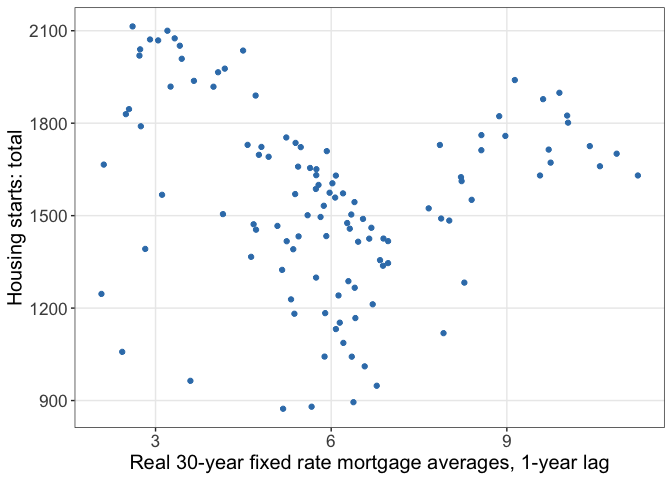

```r
df_lag %>%
  select(DATE, houst, rm30, rm30_lag_4q) %>%
  ggplot(aes(x = rm30_lag_4q, y = houst)) +
  geom_point(color = "#377EB8") +
  labs(x = "Real 30-year fixed rate mortgage averages, 1-year lag",
       y = "Housing starts: total") +
  theme_bw() +
  theme(panel.grid.minor = element_blank(),
        axis.title = element_text(size = 15),
        axis.text = element_text(size = 13))
```

```r
ggsave("rm30_lag_4q_x_houst.pdf", width = 9, height = 7, units = "in")
```

## scatter of rm30 diffs x houst diffs

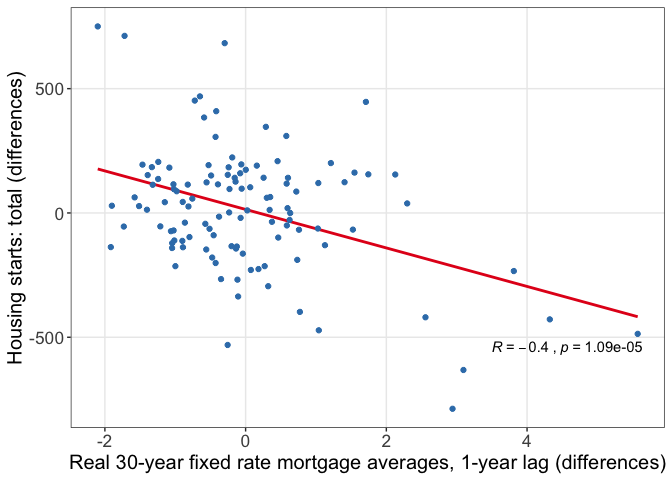

```r
df_lag_diffs %>%
  select(DATE, rm30_lag_diff_4q, houst_lag_diff_4q) %>%
  ggplot(aes(x = rm30_lag_diff_4q, y = houst_lag_diff_4q)) +
  geom_smooth(method='lm', se = FALSE, color = "#E41A1C") +
  geom_point(color = "#377EB8") +
  stat_cor(method = "pearson", r.digits = 2, p.digits = 3, label.x = 3.5, label.y = -540) +
  labs(x = "Real 30-year fixed rate mortgage averages, 1-year lag (differences)",
       y = "Housing starts: total (differences)") +
  theme_bw() +
  theme(panel.grid.minor = element_blank(),
        axis.title = element_text(size = 15),
        axis.text = element_text(size = 13))
```

```r
ggsave("rm30_lagdiff4q_x_houst_lagdiff4q.pdf", width = 9, height = 7, units = "in")
```